# Topic 4 - Classification using Naive Bayes and LDA - lab

MSDA7003 - Machine Learning

KT Wong

Faculty of Social Sciences, HKU

2024-10-25

The materials in this topic are drawn from Lantz (2023) and James et al. (2023)

# Tutorial lab

- we will carry onward analysis on the Smarket dataset using LDA and QDA
- and then we do analysis using Naive Bayes

## Linear Discriminant Analysis

```r
library(knitr)
library(tidyverse)
library(MASS)

smarket <- read.csv("https://raw.githubusercontent.com/kwan-MSDA/MSDA7003/main/Smarket.csv")

train <- (smarket$Year < 2005)

lda_fit <- lda(Direction ~ Lag1 + Lag2, data = smarket, subset = train)

lda_fit
```

```
Call:
lda(Direction ~ Lag1 + Lag2, data = smarket, subset = train)

Prior probabilities of groups:
    Down       Up
0.491984 0.508016

Group means:
            Lag1        Lag2
Down  0.04279022  0.03389409
Up   -0.03954635 -0.03132544

Coefficients of linear discriminants:
            LD1
Lag1 -0.6420190
Lag2 -0.5135293
```

## Linear Discriminant Analysis

```r
pred <- predict(lda_fit, smarket[!train, ])

pred_df<- data.frame(pred$class, pred_posterior=pred$posterior[, 1], pred$x)

lda_pred <- smarket %>%  filter(train==0) %>%
  bind_cols(pred_df)

str(lda_pred)
```

```
'data.frame':   252 obs. of  12 variables:
 $ Year          : int  2005 2005 2005 2005 2005 2005 2005 2005 2005 2005 ...
 $ Lag1          : num  -0.134 -0.812 -1.167 -0.363 0.351 ...
 $ Lag2          : num  0.008 -0.134 -0.812 -1.167 -0.363 ...
 $ Lag3          : num  -0.007 0.008 -0.134 -0.812 -1.167 ...
 $ Lag4          : num  0.715 -0.007 0.008 -0.134 -0.812 ...
 $ Lag5          : num  -0.431 0.715 -0.007 0.008 -0.134 ...
 $ Volume        : num  0.787 1.511 1.721 1.739 1.569 ...
 $ Today         : num  -0.812 -1.167 -0.363 0.351 -0.143 ...
 $ Direction     : chr  "Down" "Down" "Down" "Up" ...
 $ pred.class    : Factor w/ 2 levels "Down","Up": 2 2 2 2 2 2 2 2 2 2 ...
 $ pred_posterior: num  0.49 0.479 0.467 0.474 0.493 ...
 $ LD1           : num  0.0829 0.5911 1.1672 0.8334 -0.0379 ...
```

## Linear Discriminant Analysis

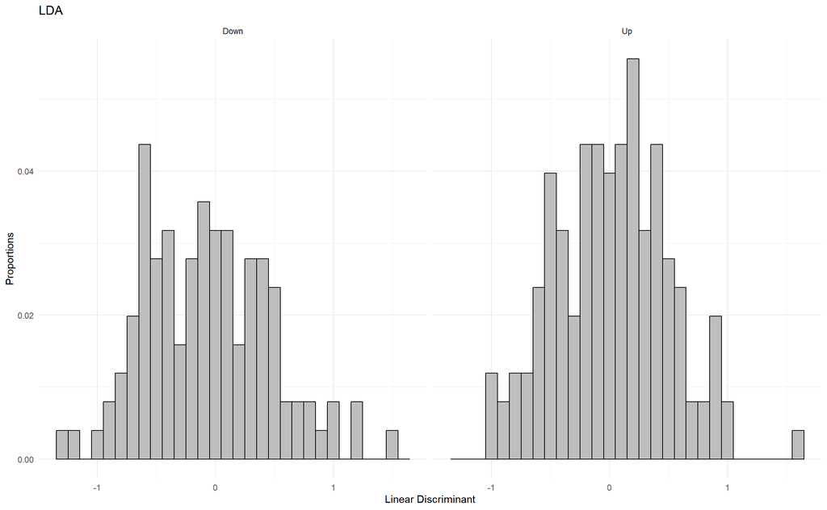

```r
ggplot(lda_pred, aes(x = LD1)) +
  geom_histogram(aes(y=(..count..)/sum(..count..)), fill="grey", color="black")+
  labs(title="LDA", x="Linear Discriminant", y="Proportions")+
  theme_minimal()+
    facet_wrap(~Direction)+
    ggtitle("LDA")
```

## Linear Discriminant Analysis - evaluation

```r
lda_class<- as.factor(lda_pred$pred.class)
table(lda_class, lda_pred$Direction)
```

```
lda_class Down  Up
     Down   35  35
     Up     76 106
```

```r
mean(lda_class == lda_pred$Direction)
```

```
[1] 0.5595238
```

- Applying a $50$ % threshold to the posterior probabilities allows us to recreate the predictions contained in `lda_pred$class`

```r
sum(lda_pred$pred_posterior >= .5)
```

```
[1] 70
```

```r
sum(lda_pred$pred_posterior < .5)
```

```
[1] 182
```

## Linear Discriminant Analysis - evaluation

- Notice that the posterior probability output by the model corresponds to the probability that the market will *decrease*:

```r
lda_pred$pred_posterior[1:20]
```

```
 [1] 0.4901792 0.4792185 0.4668185 0.4740011 0.4927877 0.4938562 0.4951016
 [8] 0.4872861 0.4907013 0.4844026 0.4906963 0.5119988 0.4895152 0.4706761
[15] 0.4744593 0.4799583 0.4935775 0.5030894 0.4978806 0.4886331
```

```r
lda_class[1:20]
```

```
 [1] Up   Up   Up   Up   Up   Up   Up   Up   Up   Up   Up   Down Up   Up   Up
[16] Up   Up   Down Up   Up
Levels: Down Up
```

## Linear Discriminant Analysis - evaluation

- We can use a posterior probability threshold other than $50$ % in order to make predictions
  - For instance, we wish to predict a market decrease only if we are very certain that the market will indeed decrease on that day
    - say, if the posterior probability is at least $90$ %

```r
sum(lda_pred$pred_posterior > .9)
```

```
[1] 0
```

- No days in 2005 meet that threshold!
- In fact, the greatest posterior probability of decrease in all of 2005 was $52.02$ %.

## Quadratic Discriminant Analysis

- now fit a QDA model to the `Smarket` data
- QDA is implemented in `R` using the `qda()` function (part of the `MASS` library)

```r
qda_fit <- qda(Direction ~ Lag1 + Lag2, data = smarket,
    subset = train)
qda_fit
```

```
Call:
qda(Direction ~ Lag1 + Lag2, data = smarket, subset = train)

Prior probabilities of groups:
    Down       Up
0.491984 0.508016

Group means:
            Lag1        Lag2
Down  0.04279022  0.03389409
Up   -0.03954635 -0.03132544
```

## Quadratic Discriminant Analysis

```r
qda_class <- predict(qda_fit, smarket[!train,])$class
table(qda_class, smarket[!train, "Direction"])
```

```
qda_class Down  Up
     Down   30  20
     Up     81 121
```

```r
mean(qda_class == smarket[!train, "Direction"])
```

```
[1] 0.5992063
```

- the QDA predictions are accurate almost $60$ % of the time
  - This level of accuracy is quite impressive for stock market data
- This suggests that the quadratic form assumed by QDA may capture the true relationship **more accurately** than the linear forms assumed by LDA and logistic regression

## Naive Bayes

- we fit a **naive Bayes model** to the `Smarket` data
- Naive Bayes is implemented in `R` using the `naiveBayes()` function (from the `e1071` library)
  - the syntax is identical to that of `lda()` and `qda()`
- this implementation of the naive Bayes classifier models each quantitative feature using a **Gaussian distribution** in its default
  - a **kernel density method** can also be used to estimate the distributions

```r
library(e1071)

nb_fit <- naiveBayes(Direction ~ Lag1 + Lag2, data = smarket,
    subset = train)
nb_fit
```

```
Naive Bayes Classifier for Discrete Predictors

Call:
naiveBayes.default(x = X, y = Y, laplace = laplace)

A-priori probabilities:
Y
    Down       Up
0.491984 0.508016

Conditional probabilities:
      Lag1
Y             [,1]     [,2]
  Down  0.04279022 1.227446
  Up   -0.03954635 1.231668

      Lag2
Y             [,1]     [,2]
  Down  0.03389409 1.239191
  Up   -0.03132544 1.220765
```

- The output contains the estimated mean and standard deviation for each variable in each class
  - the mean for `lag 1` is $0.0428$ for `Direction=Down`
  - the standard deviation is $1.23$
- We can easily verify this with the following R code

```r
mean(smarket[train & smarket$Direction=="Down", "Lag1"])
```

```
[1] 0.04279022
```

```r
sd(smarket[train & smarket$Direction=="Down", "Lag1"])
```

```
[1] 1.227446
```

## Naive Bayes - prediction

- The `predict()` function is straightforward

```r
nb_class <- predict(nb_fit, smarket[!train, ])
table(nb_class, smarket[!train, "Direction"])
```

```
nb_class Down  Up
    Down   28  20
    Up     83 121
```

```r
mean(nb_class == smarket[!train, "Direction"])
```

```
[1] 0.5912698
```

- Naive Bayes performs very well on this data, with accurate predictions over $59\%$ of the time
  - just slightly worse than QDA, but much better than LDA

## Naive Bayes - prediction

- The `predict()` function can also generate estimates of the probability that each observation belongs to a particular class

```r
nb.preds <- predict(nb_fit, smarket[!train, ], type = "raw")
nb.preds[1:5, ]
```

```
          Down        Up
[1,] 0.4873164 0.5126836
[2,] 0.4762492 0.5237508
[3,] 0.4653377 0.5346623
[4,] 0.4748652 0.5251348
[5,] 0.4901890 0.5098110
```

## $k$-NN

- perform KNN using the `knn()` function, which is part of the `class` library

```r
library(class)
Lag1=smarket$Lag1
Lag2=smarket$Lag2
Direction=smarket$Direction

train.X <- cbind(Lag1, Lag2)[train, ]
test.X <- cbind(Lag1, Lag2)[!train, ]
train.Direction <- Direction[train]
```

- the `knn()` function can be used to predict the market’s movement for the dates in 2005

```r
set.seed(1)
knn.pred <- knn(train.X, test.X, train.Direction, k = 1)
table(knn.pred, Direction[!train])
```

```
knn.pred Down Up
    Down   43 58
    Up     68 83
```

```r
(83 + 43) / 252
```

```
[1] 0.5
```

- The results using $K=1$ are not very good, since only $50$ % of the observations are correctly predicted
- We set a random seed before we apply `knn()`
  - because if several observations are tied as nearest neighbors, then `R` will randomly break the tie
  - a seed must be set in order to ensure reproducibility of results

## $k$-NN

- we repeat the analysis using $K=3$

```r
knn.pred <- knn(train.X, test.X, train.Direction, k = 3)
table(knn.pred, Direction[!train])
```

```
knn.pred Down Up
    Down   48 54
    Up     63 87
```

```r
mean(knn.pred == Direction[!train])
```

```
[1] 0.5357143
```

- The results have improved slightly
  - But increasing $K$ further turns out to provide no further improvements
  - It appears that for this data, QDA provides the best results of the methods that we have examined so far
- In conclusion, KNN does not perform well on the `Smarket` data

## Reference

James, G., D. Witten, T. Hastie, and R. Tibshirani. 2023. *An Introduction to Statistical Learning with Applications in r*. Second edition. Springer.

Lantz, Brett. 2023. *Machine Learning with r : Learn Techniques for Building and Improving Machine Learning Models, from Data Preparation to Model Tuning, Evaluation, and Working with Big Data*. Fourth edition. Expert Insight. Birmingham, UK: Packt Publishing Limited.